# $\color{#E31A1C}{\text{Belkin}}$ vs. $\color{#6A3D9A}{\text{Elago}}$

Train the models

Murilo Miranda

2020-February-13

```r
library(here)
library(kableExtra)
library(sjPlot)
library(forcats)
library(dplyr)
library(ggplot2)
library(RColorBrewer)
library(doParallel)
library(caret)
```

# Loading data

The data has empty values and the columns are separated by semicolon. **read.csv2** function was used because it has semi-colon as default sep-argument. To solve the problem with empty values, na.strings argument was used with empty value and single space.

```
'data.frame':   15000 obs. of  7 variables:
 $ salary : num  113771 139183 101967 71761 124203 ...
 $ age    : int  59 67 53 26 46 46 34 67 71 43 ...
 $ elevel : int  3 3 2 2 3 2 2 3 2 3 ...
 $ car    : int  14 16 3 8 9 5 19 4 19 20 ...
 $ zipcode: int  6 5 8 5 0 6 8 1 4 1 ...
 $ credit : num  738 679 603 654 627 ...
 $ brand  : Factor w/ 2 levels "Belkin","Elago": 1 2 1 1 NA 2 2 NA 1 NA ...
```

# Preprocessing

### Check data types

In the data-set elevel, car and zipcode are integers. In reality, they are categorical variables, so they are converted into factor. The missing values are converted into ‘No Response’.

### Data conversions

```
     salary age elevel  car zipcode credit       brand
1 113770.67  59   Coll Merc      SE 737.93      Belkin
2 139182.77  67   Coll Niss      NW 679.31       Elago
3 101966.66  53   Prof Volk       W 602.73      Belkin
4  71760.52  26   Prof Hond      NW 653.90      Belkin
5 124202.78  46   Coll Opel       C 627.27 No Response
6  36716.54  46   Prof Chry      SE 461.72       Elago
```

### Check duplicate observations

```
[1] 0
```

### Separate the dataset into two dataset

dataSet with all information that will be used to train our models and no Response dataset as new information and we will use it to predict if those customers will prefere Belkin or Elago.

### Correlation

```
            salary         age      credit
salary 1.000000000 0.007025207 0.799999892
age    0.007025207 1.000000000 0.002744687
credit 0.799999892 0.002744687 1.000000000
```

## Distributions of the variables

### Data Frame Summary

**dataSet**  
**Dimensions:** 10000 x 7  
**Duplicates:** 0

| No | Variable | Stats / Values | Freqs (% of Valid) | Graph | Missing |
| --- | --- | --- | --- | --- | --- |
| 1 | salary [numeric] | Mean (sd) : 84897.3 (37709.8) min < med < max: 20000 < 84968.9 < 150000 IQR (CV) : 65059 (0.4) | 9757 distinct values |  | 0 (0%) |
| 2 | age [integer] | Mean (sd) : 49.8 (17.6) min < med < max: 20 < 50 < 80 IQR (CV) : 30 (0.4) | 61 distinct values |  | 0 (0%) |
| 3 | elevel [factor] | 1. Prof 2. Coll 3. HSch 4. Mast | 4404 (44.0%) 3497 (35.0%) 1435 (14.3%) 664 ( 6.6%) |  | 0 (0%) |
| 4 | car [factor] | 1. Volk 2. Hond 3. Ford 4. Daci 5. BMW 6. Kia 7. Rena 8. Audi 9. Toyo 10. Chry [ 10 others ] | 846 ( 8.5%) 759 ( 7.6%) 719 ( 7.2%) 740 ( 7.4%) 632 ( 6.3%) 643 ( 6.4%) 555 ( 5.5%) 443 ( 4.4%) 422 ( 4.2%) 446 ( 4.5%) 3795 (38.0%) |  | 0 (0%) |
| 5 | zipcode [factor] | 1. SE 2. W 3. N 4. NW 5. E 6. SW 7. NE 8. C 9. EC | 1167 (11.7%) 1144 (11.4%) 1103 (11.0%) 1113 (11.1%) 1125 (11.2%) 1091 (10.9%) 1094 (10.9%) 1097 (11.0%) 1066 (10.7%) |  | 0 (0%) |
| 6 | credit [numeric] | Mean (sd) : 635.6 (87.3) min < med < max: 423.7 < 635.5 < 849 IQR (CV) : 126.9 (0.1) | 8658 distinct values |  | 0 (0%) |
| 7 | brand [factor] | 1. Belkin 2. Elago | 4652 (46.5%) 5348 (53.5%) |  | 0 (0%) |

# Exploratory Data Analysis

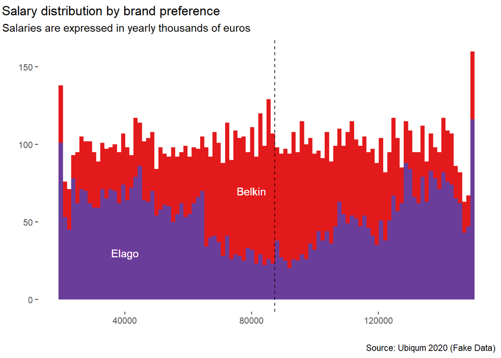

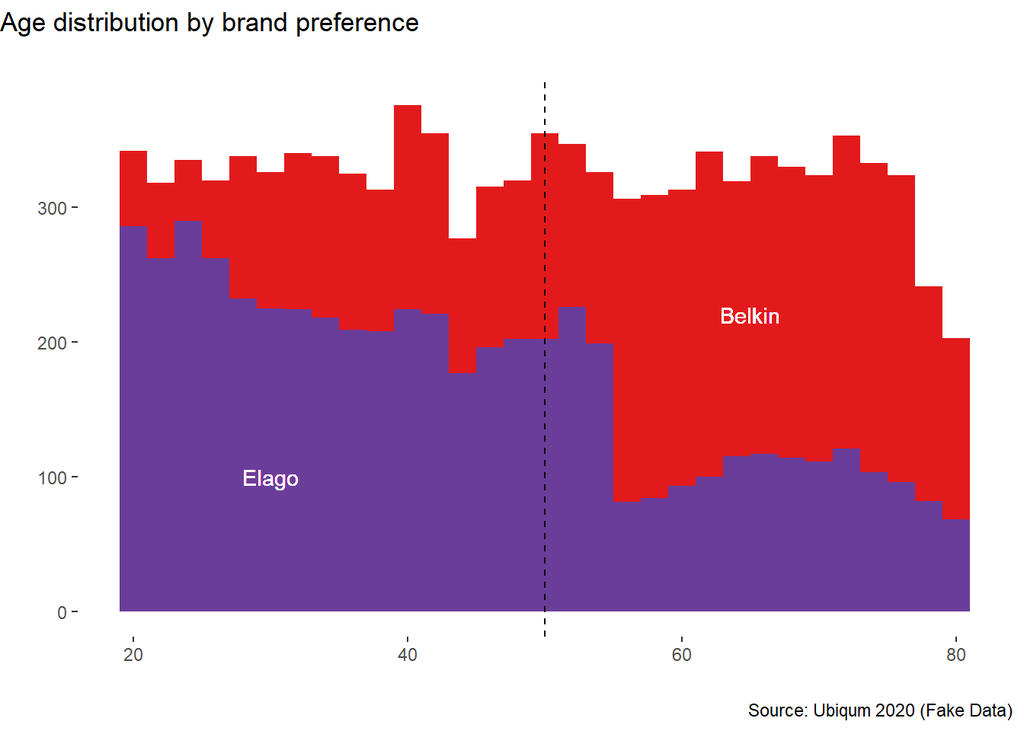

### Model Hypothesis Testing

The null hypothesis ($H_0$): age and educational level don’t affect salary, and the alternative hypothesis ($H_1$): age or educational level do affect the salary amount.

|  | salary |  |  |
| --- | --- | --- | --- |
| Predictors | Estimates | Conf. Int (95%) | P-Value |
| Intercept | 72345.26 | 70676.97 – 74013.55 | **<0.001** |
| Age | 4.75 | -24.93 – 34.44 | 0.754 |
| College Degree | 36160.17 | 34977.33 – 37343.00 | **<0.001** |
| High School Degree | -31503.43 | -33090.80 – -29916.06 | **<0.001** |
| Master’s Degree | 63112.91 | 60938.73 – 65287.09 | **<0.001** |
| Observations | 10000 |  |  |
| R<sup>2</sup> / R<sup>2</sup> adjusted | 0.501 / 0.501 |  |  |

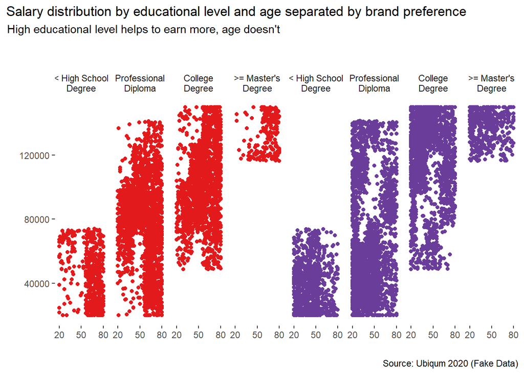

### Conclusion

There are more people with **Professional Diploma**, followed by **College Degree**, **High School Degree or lower**, finnally, **Master’s Degree or Higher**. Age at educational level is equally distributed.

Older people and people with intermediate income are associated with the $\color{#E31A1C}{\text{Belkin}}$ brand and younger people and people with low or high income are associated with the $\color{#6A3D9A}{\text{Elago}}$ brand.

# Preprocessing 2

Some variables have different units and variance, so we will scale and center the numerical data by using the convenient preprocess() in **caret**. We will also remove variables that only have a single unique value (i.e. a “zero-variance predictor”) and have high correlation. For many models (excluding tree-based models), this may cause the model to crash or the fit to be unstable.

```r
# Centering and scaling numerical columns
preProcValues <- preProcess(dataSet, method = c("center","scale", "zv", "corr"))

dataSetProcessed <- predict(preProcValues, dataSet)
```

### Splitting data using caret

We will use createDataPartition() to split our data into two sets: 75% in the training set and 25% in the testing set.

```r
# Spliting training set into two parts based on outcome: 75% and 25%
index <- createDataPartition(dataSetProcessed$brand, p = 0.75, list = FALSE)
trainSet <- dataSetProcessed[ index,]
testSet <- dataSetProcessed[-index,]
```

## Training models

### Train Control

10-fold cross validation with one repetition.

```r
fitControl <- trainControl(method = "repeatedcv", number = 10, repeats = 1,
                           classProbs = TRUE, summaryFunction = twoClassSummary)
```

## Decision Tree

Build a model using a decision tree, C5.0, on the training set with 10-fold cross validation and an Automatic Tuning Grid with a tuneLength of 2.

```r
# set.seed(123)
# cl <- makeCluster(2)
# registerDoParallel(cl)
# dtFit <- train(brand ~ ., trainSet, method = "C5.0", trControl = fitControl,
#                tuneLength = 2, metric = "ROC")
# stopCluster(cl)
# saveRDS(dtFit, "decisionTreeC5.RDS")
dtFit <- readRDS("decisionTreeC5.RDS")
#summary(dtFit)
#ggplot(dtFit)
```

```r
dtBrand <- predict(dtFit, newdata = testSet)
#dtProbs <- predict(dtFit, newdata = testSet, type = "prob")

confusionMatrix(dtBrand, testSet$brand)
```

```
Confusion Matrix and Statistics

          Reference
Prediction Belkin Elago
    Belkin   1044   358
    Elago     119   979

               Accuracy : 0.8092
                 95% CI : (0.7932, 0.8244)
    No Information Rate : 0.5348
    P-Value [Acc > NIR] : < 2.2e-16

                  Kappa : 0.6216

 Mcnemar's Test P-Value : < 2.2e-16

            Sensitivity : 0.8977
            Specificity : 0.7322
         Pos Pred Value : 0.7447
         Neg Pred Value : 0.8916
             Prevalence : 0.4652
         Detection Rate : 0.4176
   Detection Prevalence : 0.5608
      Balanced Accuracy : 0.8150

       'Positive' Class : Belkin
```

## Random Forest

Build a decision tree using Random Forest with 10-fold cross validation and manually tune 5 different mtry values.

### Parameter Tuning

Manually tune 5 different mtry values (2, 3, 4, 5, 6).

```r
rfGrid <- expand.grid(mtry = c(2, 3, 4, 5, 6))
```

```r
# set.seed(123)
# cl <- makeCluster(2)
# registerDoParallel(cl)
# rfFit <- train(brand ~ ., trainSet, method = "rf", trControl = fitControl,
#                tuneGrid = rfGrid, metric = "ROC")
# stopCluster(cl)
# saveRDS(rfFit, "randomForest.RDS")
rfFit <- readRDS("randomForest.RDS")
#rfFit
#ggplot(rfFit)
```

```r
rfBrand <- predict(rfFit, newdata = testSet)
#rfProbs <- predict(rfFit, newdata = testSet, type = "prob")

confusionMatrix(rfBrand, testSet$brand)
```

```
Confusion Matrix and Statistics

          Reference
Prediction Belkin Elago
    Belkin   1095   104
    Elago      68  1233

               Accuracy : 0.9312
                 95% CI : (0.9206, 0.9408)
    No Information Rate : 0.5348
    P-Value [Acc > NIR] : < 2.2e-16

                  Kappa : 0.862

 Mcnemar's Test P-Value : 0.007614

            Sensitivity : 0.9415
            Specificity : 0.9222
         Pos Pred Value : 0.9133
         Neg Pred Value : 0.9477
             Prevalence : 0.4652
         Detection Rate : 0.4380
   Detection Prevalence : 0.4796
      Balanced Accuracy : 0.9319

       'Positive' Class : Belkin
```

### Variable Importance

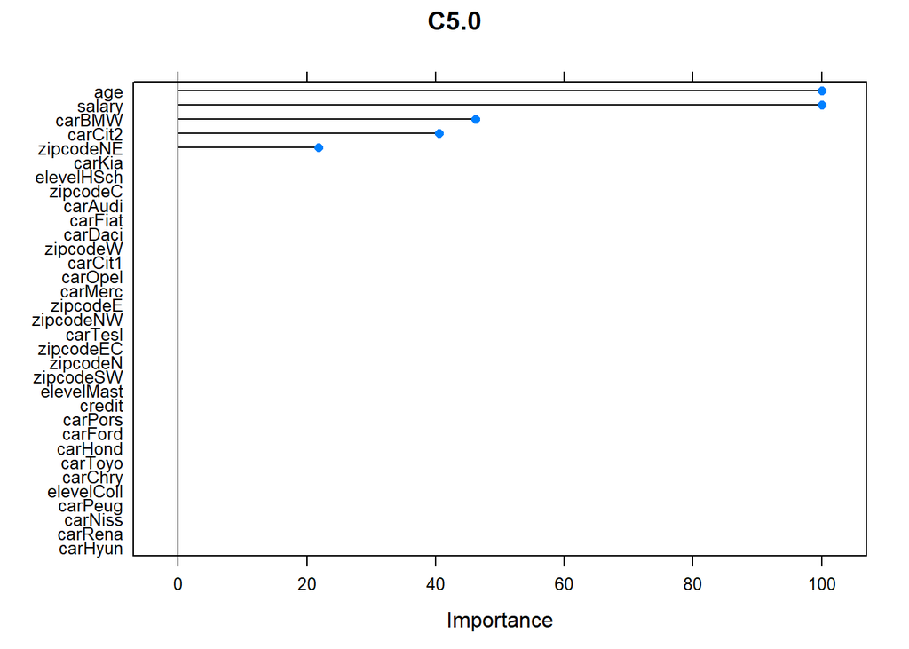

```r
par(mfrow=c(1,2))

plot(varImp(dtFit), main = "C5.0")
```

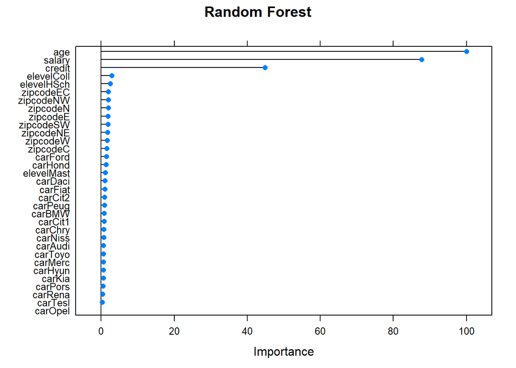

```r
plot(varImp(rfFit), main = "Random Forest")
```

## Comparing models

```r
resamps <- resamples((list(dt = dtFit, rf = rfFit)))

summary(resamps)
```

```
Call:
summary.resamples(object = resamps)

Models: dt, rf
Number of resamples: 10

ROC
        Min.   1st Qu.    Median      Mean   3rd Qu.      Max. NA's
dt 0.8364976 0.8478696 0.8633699 0.8592689 0.8700151 0.8749795    0
rf 0.8347844 0.8400871 0.8550043 0.8532045 0.8659824 0.8672266    0

Sens
        Min.   1st Qu.    Median      Mean   3rd Qu.      Max. NA's
dt 0.7557471 0.7879656 0.8037249 0.8237122 0.8717765 0.9083095    0
rf 0.8194842 0.8295129 0.8338109 0.8435118 0.8566306 0.8796562    0

Spec
        Min.   1st Qu.    Median      Mean   3rd Qu.      Max. NA's
dt 0.6932668 0.7213217 0.7493766 0.7452104 0.7749377 0.7880299    0
rf 0.6832918 0.7144638 0.7244389 0.7282540 0.7500000 0.7605985    0
```

```r
#xyplot(resamps,what = "BlandAltman")

diffs <- diff(resamps)
summary(diffs)
```

```
Call:
summary.diff.resamples(object = diffs)

p-value adjustment: bonferroni
Upper diagonal: estimates of the difference
Lower diagonal: p-value for H0: difference = 0

ROC
   dt       rf
dt          0.006064
rf 0.009227

Sens
   dt     rf
dt        -0.0198
rf 0.2898

Spec
   dt     rf
dt        0.01696
rf 0.1056
```

# Combining all surveys (Complete and Incomplete)

## Predict brand variable for incomplete survey

ROC shows that decision tree is better than random forest (diff = 0.006, p < 0.05), but sensitivity and specificity are no statistically different (p = 0.290 and p = 0.106, respectively). Therefore, we use decision tree to predict the missing information in the survey.

```r
noRespProcessed <- predict(preProcValues, noResponse)
newBrand <- predict(dtFit, newdata = noRespProcessed)

newBrand <- cbind(noResponse[, -7], brand = newBrand)

newDataSet <- rbind(dataSet, newBrand)
```

### Distributions of the variables

### Data Frame Summary

**newDataSet**  
**Dimensions:** 15000 x 7  
**Duplicates:** 0

| No | Variable | Stats / Values | Freqs (% of Valid) | Graph | Missing |
| --- | --- | --- | --- | --- | --- |
| 1 | salary [numeric] | Mean (sd) : 87233.6 (37925.2) min < med < max: 19582.9 < 87244 < 161748 IQR (CV) : 65426.1 (0.4) | 14757 distinct values |  | 0 (0%) |
| 2 | age [integer] | Mean (sd) : 49.8 (17.6) min < med < max: 20 < 50 < 80 IQR (CV) : 30 (0.4) | 61 distinct values |  | 0 (0%) |
| 3 | elevel [factor] | 1. Prof 2. Coll 3. HSch 4. Mast | 6584 (43.9%) 5416 (36.1%) 1991 (13.3%) 1009 ( 6.7%) |  | 0 (0%) |
| 4 | car [factor] | 1. Volk 2. Hond 3. Ford 4. Daci 5. BMW 6. Kia 7. Rena 8. Audi 9. Toyo 10. Chry [ 10 others ] | 1293 ( 8.6%) 1121 ( 7.5%) 1082 ( 7.2%) 1076 ( 7.2%) 966 ( 6.4%) 863 ( 5.8%) 757 ( 5.0%) 686 ( 4.6%) 661 ( 4.4%) 658 ( 4.4%) 5837 (38.9%) |  | 0 (0%) |
| 5 | zipcode [factor] | 1. SE 2. W 3. N 4. NW 5. E 6. SW 7. NE 8. C 9. EC | 1709 (11.4%) 1707 (11.4%) 1688 (11.2%) 1681 (11.2%) 1670 (11.1%) 1662 (11.1%) 1642 (10.9%) 1626 (10.8%) 1615 (10.8%) |  | 0 (0%) |
| 6 | credit [numeric] | Mean (sd) : 638.9 (86.7) min < med < max: 423.7 < 638.3 < 849 IQR (CV) : 125.9 (0.1) | 11999 distinct values |  | 0 (0%) |
| 7 | brand [factor] | 1. Belkin 2. Elago | 7458 (49.7%) 7542 (50.3%) |  | 0 (0%) |

# Exploratory Data Analysis

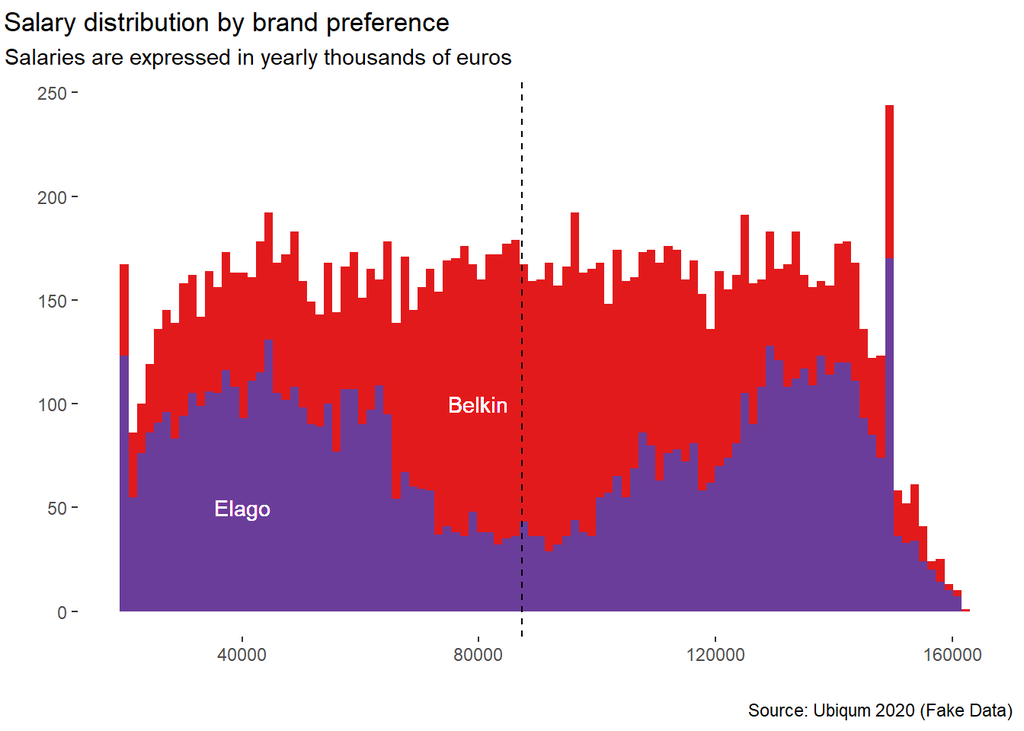

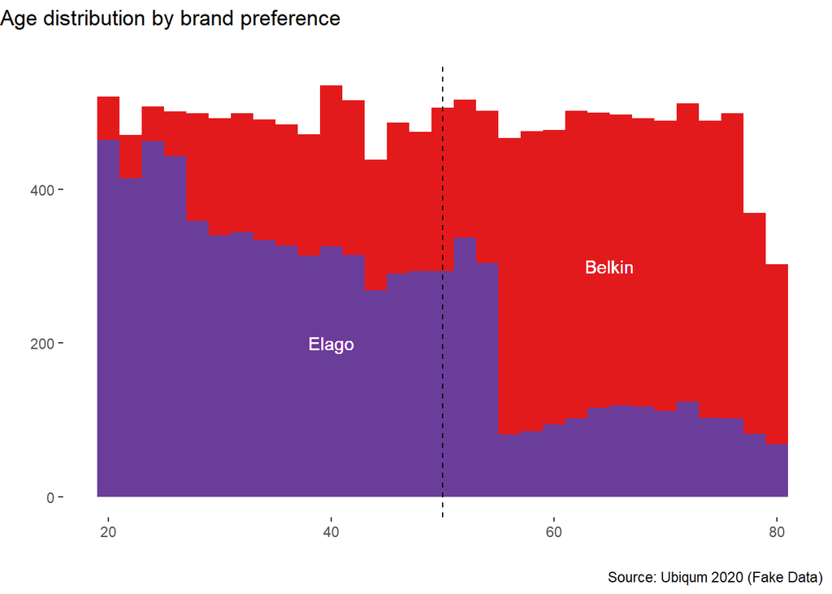

### Model Hypothesis Testing

The null hypothesis ($H_0$): Salary of customers are equal between brand, and the alternative hypothesis ($H_1$): Salary of customers are diferent between brand.

```
    Welch Two Sample t-test

data:  salary by brand
t = 2.2554, df = 14093, p-value = 0.02412
alternative hypothesis: true difference in means is not equal to 0
95 percent confidence interval:
  182.5902 2606.5913
sample estimates:
mean in group Belkin  mean in group Elago
            87934.83             86540.24
```

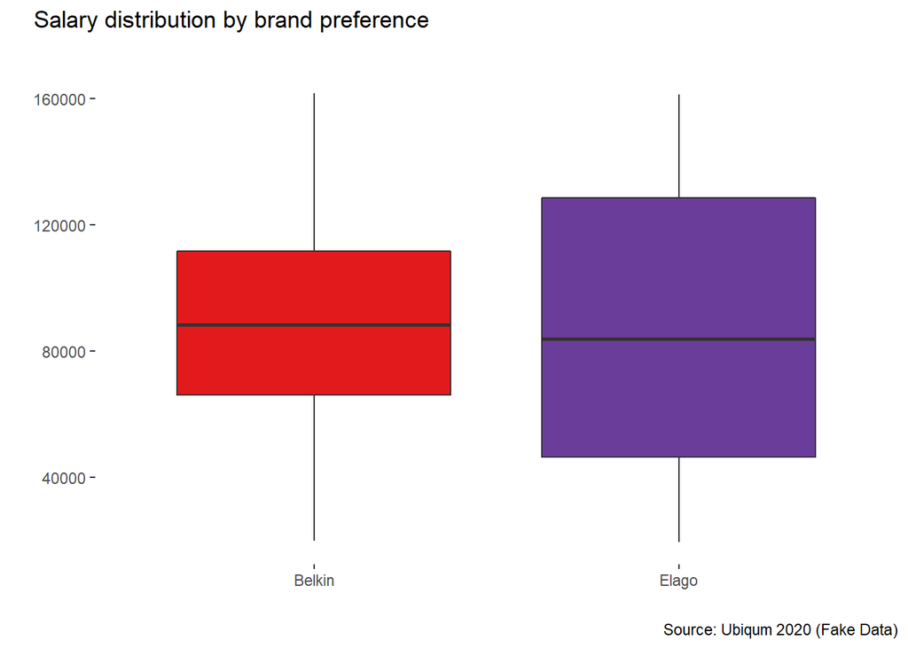

### Conclusion

There is no big difference between models. On average, the ROC for decision tree is 0.859 and for Random forest is 0.853 (p = 0.009). Decision tree C5.0 shows that salary, age, some car models (BMW and Citroen) and Northeastern Europe region are the most important variables. Random forest also shows that salary and age are the most important variables.